# 4 Calculus

## 4.1 Differentiation

> *How do we differentiate functions numerically?*

### 4.1.1 Basics

The definition of the derivative as
$$f'(x_0) = \lim_{h\to 0}\frac{f(x_0+h) - f(x_0)}{h},$$
suggests an obvious approximation: just pick some small finite $h$ to give the estimate
$$f'(x_0) \approx \frac{f(x_0 + h) - f(x_0)}{h}.$$
For $h>0$ this is called a **forward difference** (and, for $h<0$, a **backward difference**). It is an example of a **finite-difference formula**.

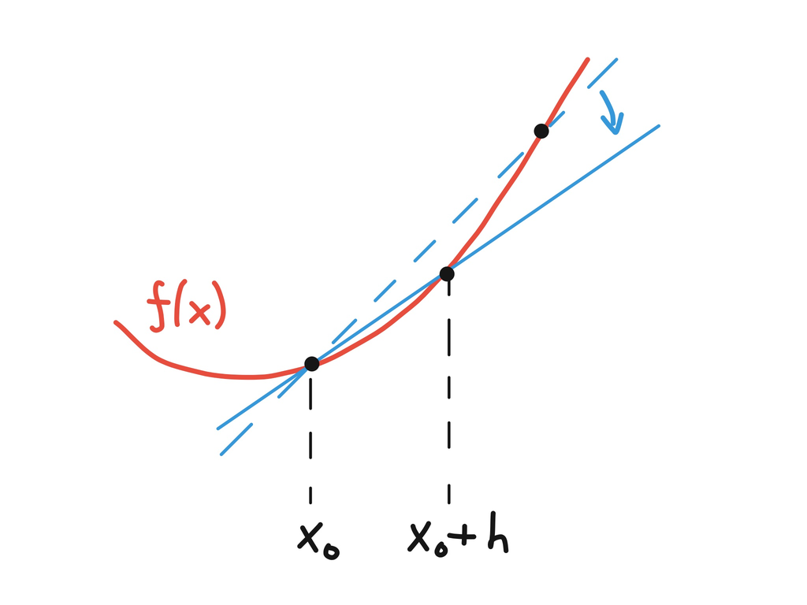

Of course, what we are doing with the forward difference is approximating $f'(x_0)$ by the slope of the linear interpolant for $f$ at the nodes $x_0$ and $x_1=x_0 + h$. So we could also have derived the forward difference formula by starting with the Lagrange form of the interpolating polynomial,
$$f(x) = \frac{x-x_1}{x_0-x_1}f(x_0) + \frac{x-x_0}{x_1-x_0}f(x_1) + \frac{f''(\xi)}{2}(x-x_0)(x-x_1)$$
for some $\xi\in[x_0,x_1]$. Differentiating – and remembering that $\xi$ depends on $x$, so that we need to use the chain rule – we get
$$\begin{aligned}
f'(x) &= \frac{1}{x_0-x_1}f(x_0) + \frac{1}{x_1-x_0}f(x_1) + \frac{f''(\xi)}{2}(2x - x_0 - x_1) \\
&\quad + \frac{f'''(\xi)}{2}\left(\frac{\mathrm{d}\xi}{\mathrm{d}x}\right)(x-x_0)(x-x_1),\\
&\implies f'(x_0) = \frac{f(x_1) - f(x_0)}{x_1-x_0} + f''(\xi)\frac{x_0-x_1}{2}.
\end{aligned}$$
Equivalently,
$$f'(x_0) = \frac{f(x_0+h)-f(x_0)}{h} - f''(\xi)\frac{h}{2}.$$
This shows that the **truncation error** for our forward difference approximation is $-f''(\xi)h/2$, for some $\xi\in[x_0,x_0+h]$. In other words, a smaller interval or a less “wiggly” function will lead to a better estimate, as you would expect.

Another way to estimate the truncation error is to use Taylor’s theorem, which tells us that
$$f(x_0+h) = f(x_0) + h f'(x_0) + h^2\frac{f''(\xi)}{2},$$
for some $\xi$ between $x_0$ and $x_0+h$. Rearranging this will give back the forward difference error formula.

**Example 4.1:** Derivative of $f(x)=\log(x)$ at $x_0=2$.**

Using a forward-difference, we get the following sequence of approximations:

| $h$ | Forward difference | Truncation error |
| --- | --- | --- |
| 1 | 0.405465 | 0.0945349 |
| 0.1 | 0.487902 | 0.0120984 |
| 0.01 | 0.498754 | 0.00124585 |
| 0.001 | 0.499875 | 0.000124958 |

Indeed the error is linear in $h$, and we estimate that it is approximately $0.125 h$ when $h$ is small. This agrees with the error formula above, since $f''(x) = -x^{-2}$, so we expect $-f''(\xi)/2\approx \tfrac18$.

Since the error is linearly proportional to $h$, the approximation is called **linear**, or **first order**.

### 4.1.2 Higher-order finite differences

To get a higher-order approximation, we can differentiate a higher degree interpolating polynomial. This means that we need more nodes.

**Example 4.2:** Central difference**

Take three nodes $x_0$, $x_1=x_0+h$, and $x_2=x_0+2h$. Then the Lagrange form of the interpolating polynomial is
$$\begin{aligned}
f(x) &= \frac{(x-x_1)(x-x_2)}{(x_0-x_1)(x_0-x_2)}f(x_0) + \frac{(x-x_0)(x-x_2)}{(x_1-x_0)(x_1-x_2)}f(x_1)\\ &+ \frac{(x-x_0)(x-x_1)}{(x_2-x_0)(x_2-x_1)}f(x_2) \\
&+ \frac{f'''(\xi)}{3!}(x-x_0)(x-x_1)(x-x_2).
\end{aligned}$$
Differentiating, we get
$$\begin{aligned}
f'(x) &= \frac{2x - x_1 - x_2}{(x_0-x_1)(x_0-x_2)}f(x_0)\\ &+ \frac{2x - x_0 - x_2}{(x_1-x_0)(x_1-x_2)}f(x_1)\\ &+ \frac{2x-x_0-x_1}{(x_2-x_0)(x_2-x_1)}f(x_2)\\
&+ \frac{f'''(\xi)}{6}\Big((x-x_1)(x-x_2) + (x-x_0)(x-x_2) + (x-x_0)(x-x_1) \Big) \\
&+ \frac{f^{(4)}(\xi)}{6}\left(\frac{\mathrm{d}\xi}{\mathrm{d}x}\right)(x-x_0)(x-x_1)(x-x_2).
\end{aligned}$$
Now substitute in $x=x_1$ to evaluate this at the central point:
$$\begin{aligned}
f'(x_1) &= \frac{x_1 - x_2}{(x_0-x_1)(x_0-x_2)}f(x_0)\\ &+ \frac{2x_1 - x_0 - x_2}{(x_1-x_0)(x_1-x_2)}f(x_1) + \frac{x_1-x_0}{(x_2-x_0)(x_2-x_1)}f(x_2)\\
&+ \frac{f'''(\xi)}{6}(x_1-x_0)(x_1-x_2),\\
&= \frac{-h}{2h^2}f(x_0) + 0 + \frac{h}{2h^2}f(x_2) - \frac{f'''(\xi)}{6}h^2\\
&= \frac{f(x_1+h) - f(x_1-h)}{2h} - \frac{f'''(\xi)}{6}h^2.
\end{aligned}$$
This is called a **central difference** approximation for $f'(x_1)$, and is frequently used in practice.

To see the quadratic behaviour of the truncation error, go back to our earlier example.

**Example 4.3:** Derivative of $f(x)=\log(x)$ at $x=2$**

| $h$ | Forward difference | Truncation error | Central difference | Truncation error |
| --- | --- | --- | --- | --- |
| 1 | 0.405465 | 0.0945349 | 0.549306 | -0.0493061 |
| 0.1 | 0.487902 | 0.0120984 | 0.500417 | -0.000417293 |
| 0.01 | 0.498754 | 0.00124585 | 0.500004 | -4.16673e-06 |
| 0.001 | 0.499875 | 0.000124958 | 0.500000 | -4.16666e-08 |

The truncation error for the central difference is about $0.04h^2$, which agrees with the formula since $f'''(\xi)\approx 2/2^3 = \tfrac14$ when $h$ is small.

### 4.1.3 Rounding error

The problem with numerical differentiation is that it involves subtraction of nearly-equal numbers. As $h$ gets smaller, the problem gets worse.

To quantify this for the central difference, suppose that we have the correctly rounded values of $f(x_1\pm h)$, so that
$$\text{fl}[f(x_1+h)] = (1+\delta_1)f(x_1+h),\qquad
\text{fl}[f(x_1-h)]=(1+\delta_2)f(x_1-h),$$
where $|\delta_1|,|\delta_2|\leq \epsilon_{\rm M}$. Ignoring the rounding error in dividing by $2h$, we then have that
$$\begin{aligned}
&\left| f'(x_1) - \frac{\text{fl}[f(x_1+h)] - \text{fl}[f(x_1-h)]}{2h}\right| \\ = &\left| - \frac{f'''(\xi)}{6}h^2 - \frac{\delta_1f(x_1+h) - \delta_2f(x_1-h)}{2h}\right|\\
\leq &\frac{|f'''(\xi)|}{6}h^2 + \epsilon_{\rm M}\frac{|f(x_1+h)| + |f(x_1-h)|}{2h}\\
\leq &\frac{h^2}{6}\max_{[x_1-h, x_1+h]} |f'''(\xi)| + \frac{\epsilon_{\rm M}}{h}\max_{[x_1-h, x_1+h]}|f(\xi)|.
\end{aligned}$$
The first term is the truncation error, which tends to zero as $h\to 0$. But the second term is the rounding error, which tends to infinity as $h\to 0$.

**Example 4.4:** Derivative of $f(x)=\log(x)$ at $x=2$ again**

Here is a comparison of the terms in the inequality above (the red points are the left-hand side), shown on logarithmic scales, using $\xi=2$ to estimate the maxima.

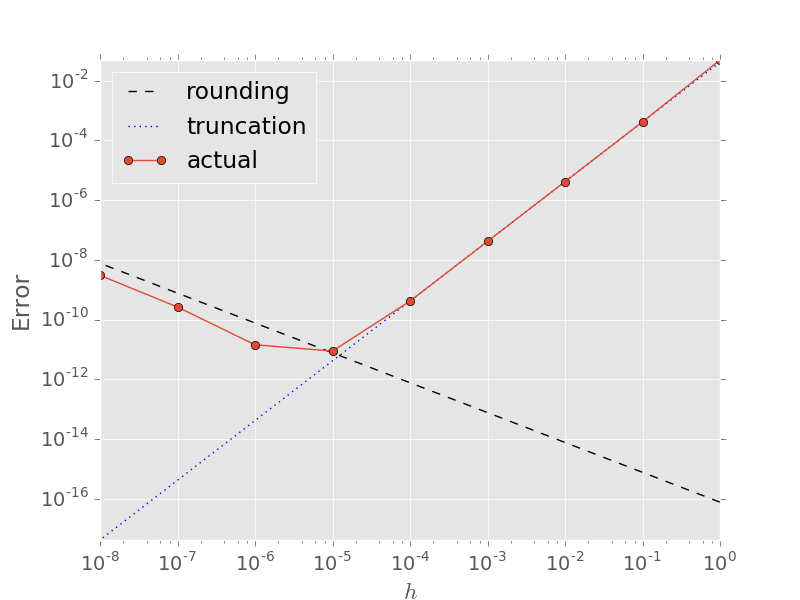

You see that once $h$ is small enough, rounding error takes over and the error in the computed derivative starts to increase again.

### 4.1.4 Richardson extrapolation

Finding higher-order formulae by differentiating Lagrange polynomials is tedious, and there is a simpler trick to obtain higher-order formulae, called **Richardson extrapolation**.

We begin from the central-difference formula. Since we will use formulae with different $h$, let us define the notation
$$D_h := \frac{f(x_1+h) - f(x_1-h)}{2h}.$$

Now use Taylor’s theorem to expand more terms in the truncation error:
$$\begin{aligned}
f(x_1 \pm h) = f(x_1) &\pm f'(x_1)h + \frac{f''(x_1)}{2}h^2 \pm \frac{f'''(x_1)}{3!}h^3 \\ &+ \frac{f^{(4)}(x_1)}{4!}h^4 \pm \frac{f^{(5)}(x_1)}{5!}h^5 + {\cal O}(h^6).
\end{aligned}$$
Substituting into the formula for $D_h$, the even powers of $h$ cancel and we get
$$\begin{aligned}
D_h &= \frac{1}{2h}\Big(2f'(x_1)h + 2f'''(x_1)\frac{h^3}{6} + 2f^{(5)}(x_1)\frac{h^5}{120} + {\cal O}(h^7) \Big)\\
&=f'(x_1) + f'''(x_1)\frac{h^2}{6} + f^{(5)}(x_1)\frac{h^4}{120} + {\cal O}(h^6).
\end{aligned}$$

You may not have seen the **big-Oh notation**. When we write $f(x) = {\cal O}(g(x))$, we mean
$$\lim_{x\to 0}\frac{|f(x)|}{|g(x)|} \leq M < \infty.$$
So the error is ${\cal O}(h^6)$ if it gets smaller at least as fast as $h^6$ as $h\to 0$ (essentially, it contains no powers of $h$ less than 6).

The leading term in the error here has the same coefficient $h^2/6$ as the truncation error we derived earlier, although we have now expanded the error to higher powers of $h$.

The trick is to apply the same formula with different step-sizes, typically $h$ and $h/2$:
$$\begin{aligned}
D_h &= f'(x_1) + f'''(x_1)\frac{h^2}{6} + f^{(5)}(x_1)\frac{h^4}{120} + {\cal O}(h^6),\\
D_{h/2} &= f'(x_1) + f'''(x_1)\frac{h^2}{2^2(6)} + f^{(5)}(x_1)\frac{h^4}{2^4(120)} + {\cal O}(h^6).
\end{aligned}$$
We can then eliminate the $h^2$ term by simple algebra:
$$\begin{aligned}
D_h - 2^2D_{h/2} =& -3f'(x_1) + \left(1 - \frac{2^2}{2^4}\right)f^{(5)}(x_1)\frac{h^4}{120} + {\cal O}(h^6),\\
\implies \quad D_h^{(1)} :=& \frac{2^2D_{h/2} - D_h}{3} = f'(x_1) - f^{(5)}(x_1)\frac{h^4}{480} + {\cal O}(h^6).
\end{aligned}$$
The new formula $D_h^{(1)}$ is 4th-order accurate.

**Example 4.5:** Derivative of $f(x)=\log(x)$ at $x=2$ (central difference).**

| $h$ | $D_h$ | Error | $D_h^{(1)}$ | Error |
| --- | --- | --- | --- | --- |
| 1.0 | 0.5493061443 | 0.04930614433 | 0.4979987836 | 0.00200121642 |
| 0.1 | 0.5004172928 | 0.00041729278 | 0.4999998434 | 1.56599487e-07 |
| 0.01 | 0.5000041667 | 4.16672916e-06 | 0.5000000000 | 1.56388791e-11 |
| 0.001 | 0.5000000417 | 4.16666151e-08 | 0.5000000000 | 9.29256672e-14 |

In fact, we could have applied this **Richardson extrapolation** procedure without knowing the coefficients of the error series. If we have some general order-$n$ approximation
$$D_h = f'(x) + Ch^n + {\cal O}(h^{n+1}),$$
then we can always evaluate it with $h/2$ to get
$$D_{h/2} = f'(x) + C\frac{h^n}{2^n} + {\cal O}(h^{n+1})$$
and then eliminate the $h^n$ term to get a new approximation
$$D_h^{(1)} := \frac{2^nD_{h/2} - D_h}{2^n - 1} = f'(x) + {\cal O}(h^{n+1}).$$

The technique is used not only in differentiation but also in **Romberg integration** and the **Bulirsch-Stoer method** for solving ODEs.

There is nothing special about taking $h/2$; we could have taken $h/3$ or even $2h$, and modified the formula accordingly. But $h/2$ is usually convenient.

Furthermore, Richardson extrapolation can be applied iteratively. In other words, we can now combine $D_{h}^{(1)}$ and $D_{h/2}^{(1)}$ to get an even higher order approximation $D_h^{(2)}$, and so on.

**Example 4.6:** Iterated Richardson extrapolation for central differences.**

From
$$\begin{aligned}
D_h^{(1)} &= f'(x_1) + C_1h^4 + {\cal O}(h^6),\\
D_{h/2}^{(1)} &= f'(x_1) + C_1\frac{h^4}{2^4} + {\cal O}(h^6),
\end{aligned}$$
we can eliminate the $h^4$ term to get the 6th-order approximation
$$D_h^{(2)} := \frac{2^4D_{h/2}^{(1)} - D_h^{(1)}}{2^4 - 1}.$$

Lewis Fry Richardson (1881–1953) was from Newcastle and an undergraduate there (when it was still a College of Durham). He was the first person to apply mathematics (finite differences) to weather prediction, and was ahead of his time: in the absence of electronic computers, he estimated that 60,000 people would be needed to predict the next day’s weather!

## 4.2 Numerical integration

> *How do we calculate integrals numerically?*

The definite integral
$$I(f) := \int_a^b f(x)\,\mathrm{d}x$$
can usually not be evaluated in closed form. To approximate it numerically, we can use a **quadrature formula**
$$I_n(f) := \sum_{k=0}^n \sigma_k f(x_k),$$
where $x_0,\ldots,x_n$ are a set of **nodes** and $\sigma_0,\ldots,\sigma_n$ are a set of corresponding **weights**.

The nodes are also known as **quadrature points** or **abscissas**, and the weights as **coefficients**.

**Example 4.7:** The trapezium rule**

$$I_1(f) = \frac{b-a}{2}\Big( f(a) + f(b) \Big).$$

This is the quadrature formula above with $x_0=a$, $x_1=b$, $\sigma_0=\sigma_1=\tfrac12(b-a)$.

For example, with $a=0$, $b=2$, $f(x)=\mathrm{e}^x$, we get
$$I_1(f) = \frac{2 - 0}{2}\big(\mathrm{e}^0 + \mathrm{e}^{2}\big) = 8.389 \quad \textrm{to 4 s.f.}$$
The exact answer is
$$I(f) = \int_0^{2}\mathrm{e}^x\,\mathrm{d}x = \mathrm{e}^{2} - \mathrm{e}^0 = 6.389 \quad \textrm{to 4 s.f.}$$
Graphically, $I_1(f)$ measures the area under the straight line that interpolates $f$ at the ends:

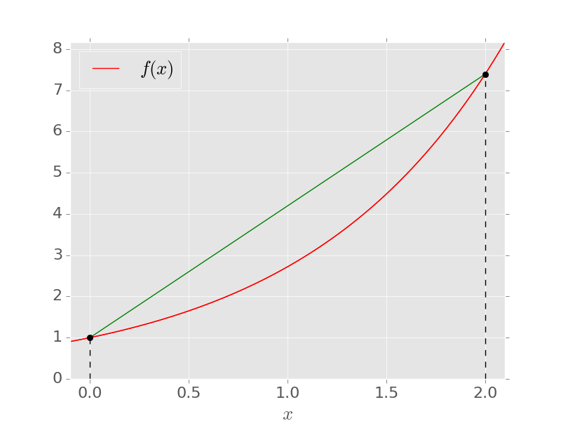

### 4.2.1 Newton-Cotes formulae

We can derive a family of “interpolatory” quadrature formulae by integrating interpolating polynomials of different degrees. We will also get error estimates using the interpolation error theorem.

Let $x_0, \ldots, x_n \in [a,b]$, where $x_0 < x_1 < \cdots < x_n$, be a set of $n+1$ nodes, and let $p_n\in{\cal P}_n$ be the polynomial that interpolates $f$ at these nodes. This may be written in Lagrange form as
$$p_n(x) = \sum_{k=0}^n f(x_k)\ell_k(x), \quad \textrm{where}\quad \ell_k(x) = \prod_{\substack{j=0\\j\neq k}}^n\frac{x - x_j}{x_k - x_j}.$$
To approximate $I(f)$, we integrate $p_n(x)$ to define the quadrature formula
$$I_n(f) := \int_a^b\sum_{k=0}^n f(x_k)\ell_k(x)\,\mathrm{d}x = \sum_{k=0}^n f(x_k)\int_a^b\ell_k(x)\,\mathrm{d}x.$$
In other words,
$$I_n(f) := \sum_{k=0}^n\sigma_k f(x_k), \quad \textrm{where} \quad \sigma_k = \int_a^b\ell_k(x)\,\mathrm{d}x.$$
When the nodes are equidistant, this is called a **Newton-Cotes formula**. If $x_0=a$ and $x_n=b$, it is called a **closed Newton-Cotes formula**.

An **open Newton-Cotes formula** has nodes $x_i = a + (i+1)h$ for $h = (b-a)/(n+2)$.

**Example 4.8:** Trapezium rule**

This is the closed Newton-Cotes formula with $n=1$. To see this, let $x_0=a$, $x_1=b$. Then
$$\begin{aligned}
\ell_0(x) = \frac{x-b}{a-b} \implies \sigma_0 &= \int_a^b\ell_0(x)\,\mathrm{d}x \\ &= \frac{1}{a-b}\int_a^b(x-b)\,\mathrm{d}x \\ &= \frac{1}{2(a-b)}(x-b)^2\big|_a^b \\ &= \frac{b-a}{2},
\end{aligned}$$
and
$$\begin{aligned}
\ell_1(x) = \frac{x-a}{b-a} \implies \sigma_1 &= \int_a^b\ell_1(x)\,\mathrm{d}x \\ &= \frac{1}{b-a}\int_a^b(x-a)\,\mathrm{d}x \\ &= \frac{1}{2(b-a)}(x-a)^2\big|_a^b = \frac{b-a}{2}.
\end{aligned}$$
This gives
$$I_1(f) = \sigma_0f(a) + \sigma_1f(b) = \frac{b-a}{2}\big(f(a) + f(b)\big).$$

**Theorem 4.1**

Let $f$ be continuous on $[a,b]$ with $n+1$ continuous derivatives on $(a,b)$. Then the Newton-Cotes formula above satisfies the error bound
$$\begin{aligned}
&\big|I(f) - I_n(f)\big| \leq \\ &\frac{\max_{\xi\in[a,b]}|f^{(n+1)}(\xi)|}{(n+1)!}\int_a^b\big|(x-x_0)(x-x_1)\cdots(x-x_{n}) \big|\,\mathrm{d}x.
\end{aligned}$$

**Proof:**
First note that the error in the Newton-Cotes formula may be written
$$\begin{aligned}
\big|I(f) - I_n(f)\big| &= \left|\int_a^bf(x)\,\mathrm{d}x - \int_a^bp_n(x)\,\mathrm{d}x \right| \\
&= \left| \int_a^b\big[f(x) - p_n(x)\big]\,\mathrm{d}x\right| \\
&\leq \int_a^b\big|f(x) - p_n(x)\big|\,\mathrm{d}x.
\end{aligned}$$
Now recall the interpolation error theorem, which says that, for each $x\in[a,b]$, we can write
$$f(x) - p_n(x) = \frac{f^{(n+1)}(\xi)}{(n+1)!}(x-x_0)(x-x_1)\cdots(x-x_{n})$$
for some $\xi\in(a,b)$. The theorem simply follows by inserting this into the inequality above. $\Box$

**Example 4.9:** Trapezium rule error**

Let $M_2 = \max_{\xi\in[a,b]}|f''(\xi)|$. Here the theorem reduces to
$$\begin{aligned}
\big|I(f) - I_1(f)\big| &\leq \frac{M_2}{(1+1)!}\int_a^b\big|(x-a)(x-b)\big|\,\mathrm{d}x \\ &= \frac{M_2}{2!}\int_a^b(x-a)(b-x)\,\mathrm{d}x \\ &= \frac{(b-a)^3}{12}M_2.
\end{aligned}$$
For our earlier example with $a=0$, $b=2$, $f(x)=\mathrm{e}^x$, the estimate gives
$$\big|I(f) - I_1(f)\big| \leq \tfrac1{12}(2^3)\mathrm{e}^{2} \approx 4.926.$$
This is an overestimate of the actual error which was $\approx 2.000$.

The theorem suggests that the accuracy of $I_n$ is limited both by the smoothness of $f$ (outside our control) and by the location of the nodes $x_k$. If the nodes are free to be chosen, then we can use **Gaussian integration** (more to follow on that topic).

As with interpolation, taking a high $n$ is not usually a good idea. One can prove for the closed Newton-Cotes formula that
$$\sum_{k=0}^n|\sigma_k| \to \infty \quad \textrm{as} \quad n\to\infty.$$
This makes the quadrature vulnerable to rounding errors for large $n$.

### 4.2.2 Composite Newton-Cotes formulae

Since the Newton-Cotes formulae are based on polynomial interpolation at equally-spaced points, the results do not converge as the number of nodes increases. A better way to improve accuracy is to divide the interval $[a,b]$ into $m$ subintervals $[x_{i-1},x_i]$ of equal length
$$h := \frac{b-a}{m},$$
and use a Newton-Cotes formula of small degree $n$ on each subinterval.

**Example 4.10:** Composite trapezium rule**

Applying the trapezium rule $I_1(f)$ on each subinterval gives
$$\begin{aligned}
C_{1,m}(f) &= \frac{h}{2}\left[f(x_0) + f(x_1) + f(x_1) + f(x_2) + \ldots + f(x_{m-1}) + f(x_m) \right],\\
&= h\left[\tfrac12 f(x_0) + f(x_1) + f(x_2) + \ldots + f(x_{m-1}) + \tfrac12 f(x_m) \right].
\end{aligned}$$
We are effectively integrating a piecewise-linear approximation of $f(x)$; here we show $m=3$ for our test problem $f(x)=\mathrm{e}^x$ on $[0,2]$:

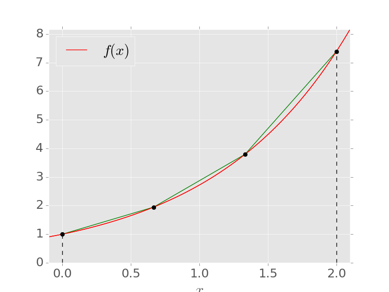

Look at what happens as we increase $m$ for our test problem:

| $m$ | $h$ | $C_{1,m}(f)$ | $\|I(f) - C_{1,m}(f)\|$ |
| --- | --- | --- | --- |
| 1 | 2 | 8.389 | 2.000 |
| 2 | 1 | 6.912 | 0.524 |
| 4 | 0.5 | 6.522 | 0.133 |
| 8 | 0.25 | 6.422 | 0.033 |
| 16 | 0.125 | 6.397 | 0.008 |
| 32 | 0.0625 | 6.391 | 0.002 |

When we halve the sub-interval $h$, the error goes down by a factor $4$, suggesting that we have quadratic convergence, i.e., ${\cal O}(h^2)$.

To show this theoretically, we can apply the Newton-Cotes error theorem in each subinterval. In $[x_{i-1},x_i]$ we have
$$\big|I(f) - I_1(f)\big| \leq \frac{\max_{\xi\in[x_{i-1},x_i]}|f''(\xi)|}{2!}\int_{x_{i-1}}^{x_i}\big|(x-x_{i-1})(x-x_i)\big|\,\mathrm{d}x$$
Note that
$$\begin{aligned}
\int_{x_{i-1}}^{x_i}\big|(x-x_{i-1})(x-x_i)\big|\,\mathrm{d}x &= \int_{x_{i-1}}^{x_i}(x-x_{i-1})(x_i-x)\,\mathrm{d}x \\
&= \int_{x_{i-1}}^{x_i}\big[-x^2 + (x_{i-1} + x_i)x - x_{i-1}x_i\big]\,\mathrm{d}x\\
&= \big[-\tfrac13x^3 + \tfrac12(x_{i-1}+x_i)x^2 - x_{i-1}x_ix\big]_{x_{i-1}}^{x_i} \\
&= \tfrac16 x_{i}^3 - \tfrac12x_{i-1}x_i^2 + \tfrac12x_{i-1}^2x_i - \tfrac16x_{i-1}^3\\
&= \tfrac16(x_i - x_{i-1})^3 = \tfrac16 h^3.
\end{aligned}$$
So overall
$$\begin{aligned}
\big| I(f) - C_{1,m}(f) \big| &\leq \tfrac12 \max_i\left(\max_{\xi\in[x_{i-1},x_i]}|f''(\xi)|\right) m\frac{h^3}{6}\\
&= \frac{mh^3}{12}\max_{\xi\in[a,b]}|f''(\xi)| = \frac{b-a}{12}h^2\max_{\xi\in[a,b]}|f''(\xi)|.
\end{aligned}$$
As long as $f$ is sufficiently smooth, this shows that the composite trapezium rule will converge as $m\to\infty$. Moreover, the convergence will be ${\cal O}(h^2)$.

### 4.2.3 Exactness

From the Newton-Cotes error theorem, we see that the Newton-Cotes formula $I_n(f)$ will give the exact answer if $f^{(n+1)}=0$. In other words, it will be exact if $f \in{\cal P}_n$.

**Example 4.11**

The trapezium rule $I_1(f)$ is exact for all linear polynomials $f\in{\cal P}_1$.

The **degree of exactness** of a quadrature formula is the largest integer $n$ for which the formula is exact for all polynomials in ${\cal P}_n$.

To check whether a quadrature formula has degree of exactness $n$, it suffices to check whether it is exact for the basis $1$, $x$, $x^2, \ldots, x^n$.

**Example 4.12:** Simpson’s rule**

This is the $n=2$ closed Newton-Cotes formula
$$I_2(f) = \frac{b-a}{6}\left[f(a) + 4f\left(\frac{a+b}{2}\right) + f(b)\right],$$
derived by integrating a quadratic interpolating polynomial. Let us find its degree of exactness:
$$\begin{aligned}
I(1) &= \int_a^b\,\mathrm{d}x = (b-a), \\
I_2(1) &= \frac{b-a}{6}[1 + 4 + 1] = b-a = I(1),\\
I(x) &= \int_a^b x\,\mathrm{d}x = \frac{b^2-a^2}{2}, \\
I_2(x) &= \frac{b-a}{6}\left[a + 2(a+b) + b\right] = \frac{(b-a)(b+a)}{2} = I(x),\\
I(x^2) &= \int_a^b x^2\,\mathrm{d}x = \frac{b^3 - a^3}{3}, \\
I_2(x^2) &= \frac{b-a}{6}\left[a^2 + (a+b)^2 + b^2\right] = \frac{2(b^3 - a^3)}{6} = I(x^2),\\
I(x^3) &= \int_a^b x^3\,\mathrm{d}x = \frac{b^4 - a^4}{4}, \\
I_2(x^3) &= \frac{b-a}{6}\left[a^3 + \tfrac12(a+b)^3 + b^3 \right] = \frac{b^4-a^4}{4} = I(x^3).
\end{aligned}$$
This shows that the degree of exactness is at least 3 (contrary to what might be expected from the interpolation picture). You can verify that $I_2(x^4)\neq I(x^4)$, so the degree of exactness is exactly 3.

This shows that the term $f'''(\xi)$ in the error formula for Simpson’s rule is misleading. In fact, it is possible to write an error bound proportional to $f^{(4)}(\xi)$.

In terms of degree of exactness, Simpson’s formula does better than expected. In general, Newton-Cotes formulae with even $n$ have degree of exactness $n+1$. But this is by no means the highest possible (see next section).

### 4.2.4 Gaussian quadrature

The idea of **Gaussian quadrature** is to choose not only the weights $\sigma_k$ but also the nodes $x_k$, in order to achieve the highest possible degree of exactness.

Firstly, we will illustrate the brute force **method of undetermined coefficients**.

**Example 4.13:** Gaussian quadrature formula $G_1(f)=\sum_{k=0}^1\sigma_kf(x_k)$ on the interval $[-1,1]$**

Here we have four unknowns $x_0$, $x_1$, $\sigma_0$ and $\sigma_1$, so we can impose four conditions:
$$\begin{aligned}
G_1(1) &= I(1) \implies \sigma_0 + \sigma_1 = \int_{-1}^1\,\mathrm{d}x = 2,\\
G_1(x) &= I(x) \implies \sigma_0x_0 + \sigma_1x_1 = \int_{-1}^1x\,\mathrm{d}x = 0,\\
G_1(x^2) &= I(x^2) \implies \sigma_0x_0^2 + \sigma_1x_1^2 = \int_{-1}^1x^2\,\mathrm{d}x = \tfrac23,\\
G_1(x^3) &= I(x^3) \implies \sigma_0x_0^3 + \sigma_1x_1^3 = \int_{-1}^1x^3\,\mathrm{d}x = 0.
\end{aligned}$$
To solve this system, the symmetry suggests that $x_1=-x_0$ and $\sigma_0=\sigma_1$. This will automatically satisfy the equations for $x$ and $x^3$, leaving the two equations
$$2\sigma_0 = 2, \qquad 2\sigma_0x_0^2 = \tfrac23,$$
so that $\sigma_0=\sigma_1=1$ and $x_1=-x_0 = 1/\sqrt{3}$. The resulting Gaussian quadrature formula is
$$G_1(f) = f\left(-\frac{1}{\sqrt{3}}\right) + f\left(\frac{1}{\sqrt{3}}\right).$$
This formula has degree of exactness 3.

The method of undetermined coefficients becomes unworkable for larger numbers of nodes, because of the nonlinearity of the equations. A much more elegant method uses orthogonal polynomials. In addition to what we learned before, we will need the following result.

**Theorem 4.2**

If $\{\phi_0,\phi_1,\ldots,\phi_n\}$ is a set of orthogonal polynomials on $[a,b]$ under the inner product $(f,g) = \int_a^b f(x)g(x)w(x)\,\mathrm{d}x$ and $\phi_k$ is of degree $k$ for each $k=0,1,\ldots,n$, then $\phi_k$ has $k$ distinct real roots, and these roots lie in the interval $[a,b]$.

**Proof:**
Let $x_1,\ldots,x_j$ be the points where $\phi_k(x)$ changes sign in $[a,b]$. If $j=k$ then we are done. Otherwise, suppose $j<k$, and consider the polynomial
$$q_j(x) = (x-x_1)(x-x_2)\cdots(x-x_j).$$
Since $q_j$ has lower degree than $\phi_k$, they must be orthogonal, meaning
$$(q_j,\phi_k)=0 \implies \int_a^b q_j(x)\phi_k(x)w(x)\,\mathrm{d}x = 0.$$
On the other hand, notice that the product $q_j(x)\phi_k(x)$ cannot change sign in $[a,b]$, because each sign change in $\phi_k(x)$ is cancelled out by one in $q_j(x)$. This means that
$$\int_a^b q_j(x)\phi_k(x)w(x)\,\mathrm{d}x \neq 0,$$
which is a contradiction. $\Box$

Remarkably, these roots are precisely the optimum choice of nodes for a quadrature formula to approximate the (weighted) integral
$$I_{w}(f) = \int_a^b f(x)w(x)\,\mathrm{d}x.$$

**Theorem 4.3:** Gaussian quadrature**

Let $\phi_{n+1}$ be a polynomial in ${\cal P}_{n+1}$ that is orthogonal on $[a,b]$ to all polynomials in ${\cal P}_{n}$, with respect to the weight function $w(x)$. If $x_0,x_1,\ldots,x_n$ are the roots of $\phi_{n+1}$, then the quadrature formula
$$G_{n,w}(f) := \sum_{k=0}^n\sigma_kf(x_k), \qquad \sigma_k = \int_a^b\ell_k(x)w(x)\,\mathrm{d}x$$
approximates $I_w(f)$ with degree of exactness ${2n+1}$ (the largest possible).

Like Newton-Cotes, we see that Gaussian quadrature is based on integrating an interpolating polynomial, but now the nodes are the roots of an orthogonal polynomial, rather than equally spaced points.

**Example 4.14:** Gaussian quadrature with $n=1$ on $[-1,1]$ and $w(x)=1$ (again)**

To find the nodes $x_0$, $x_1$, we need to find the roots of the orthogonal polynomial $\phi_2(x)$. For this inner product, we already computed this (Legendre polynomial) in Chapter 3, where we found
$$\phi_2(x) = x^2 - \tfrac13.$$
Thus the nodes are $x_0= -1/\sqrt{3}, x_1=1/\sqrt{3}$. Integrating the Lagrange polynomials gives the corresponding weights
$$\begin{aligned}
\sigma_0 &= \int_{-1}^1\ell_0(x)\,\mathrm{d}x = \int_{-1}^1\frac{x-\tfrac1{\sqrt{3}}}{-\tfrac2{\sqrt{3}}}\,\mathrm{d}x = -\tfrac{\sqrt{3}}{2}\left[\tfrac12x^2 - \tfrac1{\sqrt{3}}x\right]_{-1}^1 = 1,\\
\sigma_1 &= \int_{-1}^1\ell_1(x)\,\mathrm{d}x = \int_{-1}^1\frac{x+\tfrac1{\sqrt{3}}}{\tfrac2{\sqrt{3}}}\,\mathrm{d}x = \tfrac{\sqrt{3}}{2}\left[\tfrac12x^2 + \tfrac1{\sqrt{3}}x\right]_{-1}^1 = 1,
\end{aligned}$$
as before.

Using an appropriate weight function $w(x)$ can be useful for integrands with a singularity, since we can incorporate this in $w(x)$ and still approximate the integral with $G_{n,w}$.

**Example 4.15:** Gaussian quadrature for $\int_0^1 \cos(x)x^{-1/2}\,\mathrm{d}x$, with $n=0$**

This is a Fresnel integral, with exact value $1.80905\ldots$ Let us compare the effect of using an appropriate weight function.

1. *Unweighted quadrature ($w(x)\equiv 1$).* The orthogonal polynomial of degree 1 is
   $$\phi_1(x) = x - \frac{\int_0^1x\,\mathrm{d}x}{\int_0^1\,\mathrm{d}x} = x-\tfrac12 \implies x_0=\tfrac12.$$
   The corresponding weight may be found by imposing $G_{0}(1)=I(1)$, which gives $\sigma_0=\int_0^1\,\mathrm{d}x = 1$. Then our estimate is
   $$G_0\left(\frac{\cos(x)}{\sqrt{x}}\right) = \frac{\cos\left(\tfrac12\right)}{\sqrt{\tfrac12}} = 1.2411\ldots$$
2. *Weighted quadrature with $w(x) = x^{-1/2}$.* This time we get
   $$\phi_1(x) = x - \frac{\int_0^1x^{1/2}\,\mathrm{d}x}{\int_0^1x^{-1/2}\,\mathrm{d}x} = x-\frac{2/3}{2} \implies x_0=\tfrac13.$$
   The corresponding weight is $\sigma_0 = \int_0^1x^{-1/2}\,\mathrm{d}x = 2$, so the new estimate is the more accurate
   $$G_{0,w}\big(\cos(x)\big) = 2\cos\left(\tfrac13\right) = 1.8899\ldots$$

**Proof:**

First, recall that any interpolatory quadrature formula based on $n+1$ nodes will be exact for all polynomials in ${\cal P}_n$ (this follows from the Newton-Cotes theorem, which can be modified to include the weight function $w(x)$). So in particular, $G_{n,w}$ is exact for $p_n\in{\cal P}_n$.

Now let $p_{2n+1}\in{\cal P}_{2n+1}$. The trick is to divide this by the orthogonal polynomial $\phi_{n+1}$ whose roots are the nodes. This gives
$$p_{2n+1}(x) = \phi_{n+1}(x)q_n(x) + r_n(x) \quad \textrm{for some} \quad q_n,r_n \in{\cal P}_n.$$
Then
$$\begin{aligned}
G_{n,w}(p_{2n+1}) &= \sum_{k=0}^n\sigma_kp_{2n+1}(x_k) = \sum_{k=0}^n\sigma_k\Big[\phi_{n+1}(x_k)q_n(x_k) + r_n(x_k) \Big] \\ &= \sum_{k=0}^n\sigma_kr_n(x_k) = I_w(r_n),
\end{aligned}$$
where we have used the fact that $G_{n,w}$ is exact for $r_n\in{\cal P}_n$. Now, since $q_n$ has lower degree than $\phi_{n+1}$, it must be orthogonal to $\phi_{n+1}$, so
$$I_w(\phi_{n+1}q_n) = \int_a^b\phi_{n+1}(x)q_n(x)w(x)\,\mathrm{d}x = 0$$
and hence
$$\begin{aligned}
G_{n,w}(p_{2n+1}) &= I_w(r_n) + 0= I_w(r_n) + I_w(\phi_{n+1}q_n) \\ &= I_w( \phi_{n+1}q_n + r_n) = I_w(p_{2n+1}).
\end{aligned}$$

Unlike Newton-Cotes formulae with equally-spaced points, it can be shown that $G_{n,w}(f)\to I_w(f)$ as $n\to\infty$, for any continuous function $f$. This follows (with a bit of analysis) from the fact that all of the weights $\sigma_k$ are positive, along with the fact that they sum to a fixed number $\int_a^bw(x)\,\mathrm{d}x$. For Newton-Cotes, the signed weights still sum to a fixed number, but $\sum_{k=0}^n|\sigma_k|\to\infty$, which destroys convergence.

Not surprisingly, we can derive an error formula that depends on $f^{(2n+2)}(\xi)$ for some $\xi\in(a,b)$. To do this, we will need the following result from calculus.

**Theorem 4.4:** Mean value theorem for integrals**

If $f,g$ are continuous on $[a,b]$ and $g(x)\geq 0$ for all $x\in[a,b]$, then there exists $\xi\in(a,b)$ such that
$$\int_a^bf(x)g(x)\,\mathrm{d}x = f(\xi)\int_a^bg(x)\,\mathrm{d}x.$$

**Proof:**
Let $m$ and $M$ be the minimum and maximum values of $f$ on $[a,b]$, respectively. Since $g(x)\geq 0$, we have that
$$m\int_a^bg(x)\,\mathrm{d}x \leq \int_a^bf(x)g(x)\,\mathrm{d}x \leq M\int_a^bg(x)\,\mathrm{d}x.$$
Now let $I=\int_a^bg(x)\,\mathrm{d}x$. If $I=0$ then $g(x)\equiv 0$, so $\int_a^bf(x)g(x)\,\mathrm{d}x=0$ and the theorem holds for every $\xi\in(a,b)$. Otherwise, we have
$$m \leq \frac{1}{I}\int_a^bf(x)g(x)\,\mathrm{d}x \leq M.$$
By the Intermediate Value Theorem, $f(x)$ attains every value between $m$ and $M$ somewhere in $(a,b)$, so in particular there exists $\xi\in(a,b)$ with
$$f(\xi) = \frac{1}{I}\int_a^bf(x)g(x)\,\mathrm{d}x.$$

**Theorem 4.5:** Error estimate for Gaussian quadrature**

Let $\phi_{n+1}\in{\cal P}_{n+1}$ be monic and orthogonal on $[a,b]$ to all polynomials in ${\cal P}_n$, with respect to the weight function $w(x)$. Let $x_0,x_1,\ldots,x_n$ be the roots of $\phi_{n+1}$, and let $G_{n,w}(f)$ be the Gaussian quadrature formula defined above. If $f$ has $2n+2$ continuous derivatives on $(a,b)$, then there exists $\xi\in(a,b)$ such that
$$I_w(f) - G_{n,w}(f) = \frac{f^{(2n+2)}(\xi)}{(2n+2)!}\int_a^b\phi_{n+1}^2(x)w(x)\,\mathrm{d}x.$$

**Proof:**
A neat trick is to use Hermite interpolation. Since the $x_k$ are distinct, there exists a unique polynomial $p_{2n+1}$ such that
$$p_{2n+1}(x_k) = f(x_k), \quad p_{2n+1}'(x_k) = f'(x_k) \quad \textrm{for $k=0,\ldots,n$}.$$
In addition (see problem sheet), there exists $\lambda\in(a,b)$, depending on $x$, such that
$$f(x) - p_{2n+1}(x) = \frac{f^{(2n+2)}(\lambda)}{(2n+2)!}\prod_{i=0}^n(x-x_i)^2.$$
Now we know that $(x-x_0)(x-x_1)\cdots(x-x_n)=\phi_{n+1}(x)$, since we fixed $\phi_{n+1}$ to be monic. Hence
$$\int_a^bf(x)w(x)\,\mathrm{d}x - \int_a^bp_{2n+1}(x)w(x)\,\mathrm{d}x = \int_a^b\frac{f^{(2n+2)}(\lambda)}{(2n+2)!}\phi_{n+1}^2(x)w(x)\,\mathrm{d}x.$$
Now we know that $G_{n,w}$ must be exact for $p_{2n+1}$, so
$$\int_a^bp_{2n+1}(x)w(x)\,\mathrm{d}x = G_{n,w}(p_{2n+1}) = \sum_{k=0}^n\sigma_kp_{2n+1}(x_k) = \sum_{k=0}^n\sigma_kf(x_k)=G_{n,w}(f).$$
For the right-hand side, we can’t take $f^{(2n+2)}(\lambda)$ outside the integral since $\lambda$ depends on $x$. But $\phi_{n+1}^2(x)w(x)\geq 0$ on $[a,b]$, so we can apply the mean value theorem for integrals and get
$$I_w(f) - G_{n,w}(f) = \frac{f^{(2n+2)}(\xi)}{(2n+2)!}\int_a^b\phi_{n+1}^2(x)w(x)\,\mathrm{d}x$$
for some $\xi\in(a,b)$ that does not depend on $x$.